# communicate_data_findings slides

## Bay Wheels Bike Sharing System Usage Pattern 2019

### Investigation Overview

In this investigation, I wanted to look at the data of Ford GoBike System that could be used to predict their users behaviour. The main focus was on the four time(hour/day/month) of starting time of the ride, user type and duration.

**What is the structure of your dataset?**

#### 1. Number of rides per month

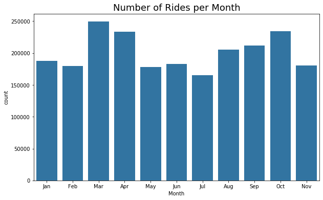

```python
figure(figsize=(10, 6))


ax = sns.countplot(x = 'month', data = df_cleaned, color = base_color)
ax.set_title("Number of Rides per Month", fontsize = 18)
plt.xlabel('Month');
```

Spring has the most rides especially in March and April followed by October that has the third most popular rides. We can conclude that during spring break, we had the most rides.

#### 2. Number of Trips per Day of the Week

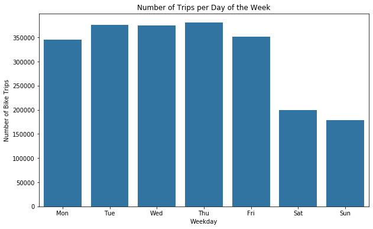

```python
# Visualizing the total number of Trips per weekday
figure(figsize=(10, 6))


ax = sns.countplot(data = df_cleaned, x='weekday', color = base_color, order = weekday)

plt.xlabel('Weekday')
plt.ylabel('Number of Bike Trips')

ax.set_title('Number of Trips per Day of the Week');
```

Thursdays and Tuesdays are the most popular days for using bikes, however Wednesday, Mondays and Fridays are very close to Tues & Weds numbers. All of that suggests that Bike usage are more usable on the workdays than weekends.

#### 3. Number of Trips per Hour

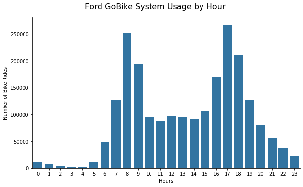

```python
# Hourly usage of the Ford Go Bike System
ax = sns.catplot(data = df_cleaned, x = 'hour', kind='count', color = base_color, aspect = 1.7)

ax.set_axis_labels('Hours', 'Number of Bike Rides')

ax.fig.suptitle('Ford GoBike System Usage by Hour', y = 1.05, fontsize = 16);
```

The most usage of bikes were in thee morning between 7 - 9 AM in the morning and 16 - 19 which is a tpyical workingday in the US and that proves our previous findings that workdays have more usage than weekends.

#### 4. Trip Duration Distribution

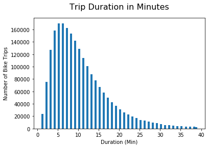

```python
# Duration of the bike rides -in MINUTES
bin_edges = np.arange(1, 39 + 0.5, 0.5)
ticks = [0, 5, 10, 15, 20, 25, 30,  35, 40]
labels = ['{}'.format(val) for val in ticks]

plt.hist(data = df_cleaned, x = 'duration', bins = bin_edges);

plt.title("Trip Duration in Minutes", y=1.05, fontsize=16)
plt.xlabel('Duration (Min)')
plt.ylabel('Number of Bike Trips');
```

The average trip is under 12.5 minutes, with 75% of trips being under 14 minutes. By Looking at the histogram, most rides fall in between the 3 - 12 minute range. We can conlcude from that riders are taking the bikes short distances.

#### 5. The Visuals of Customers vs Subscribers

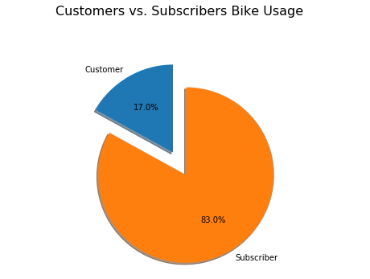

```python
# The Visuals of Customers vs Subscribers
# pie chart
plt.figure(figsize = [8, 5])

labels = ['Customer', 'Subscriber']
size = [customer_prop, subscriber_prop]
explode = (0, 0.3)

plt.pie(size, explode=explode, labels = labels, autopct='%1.1f%%', shadow = True, startangle = 90)
plt.axis('equal')

plt.suptitle('Customers vs. Subscribers Bike Usage', y = 1.05, fontsize = 16);
```

Subscribers' users had the most of bike usage with a percentage of 83%.

#### 6. Duration by user type

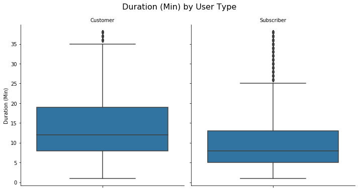

```python
data = df_cleaned.query('duration < 39')

ax = sns.catplot(data = data, y = 'duration', col = "user_type", kind='box', color = base_color)

ax.set_titles(col_template = '{col_name}')
ax.set_axis_labels("", "Duration (Min)")
ax.fig.suptitle('Duration (Min) by User Type', y=1.05, fontsize=16);
```

The boxplot shows that customers use bikes for a longer time than subscribers.

#### 7. Number of Bike Trips for every user type per hour

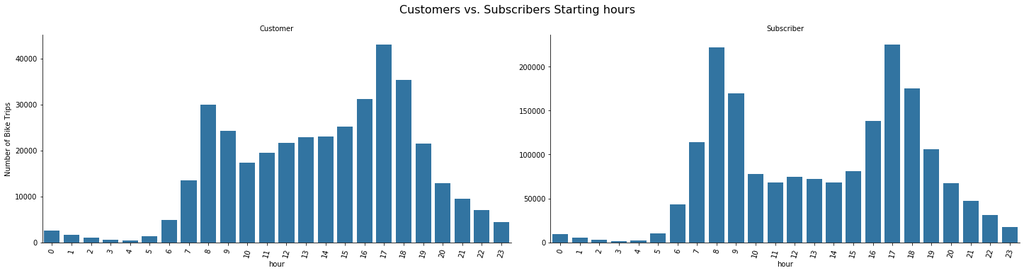

```python
# Customer vs. Subscriber usage by duration
ax = sns.catplot(data = df_cleaned, x = 'hour', col='user_type', kind='count', sharey = False, color = base_color, aspect= 2);

ax.set_axis_labels('hour', 'Number of Bike Trips')
ax.set_titles('{col_name}')

ax.fig.suptitle('Customers vs. Subscribers Starting hours', y=1.05, fontsize=16);
ax.set_xticklabels(rotation=75);
```

#### 8. The Average Trip Duration in Minutes per User Type

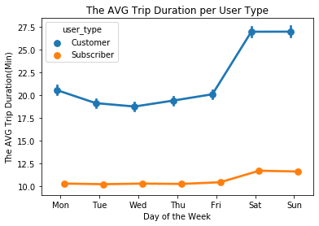

```python
sns.pointplot(data = df_cleaned, x = 'weekday', y='duration', hue='user_type', dodge=0.2)
plt.title('The AVG Trip Duration per User Type')
plt.xlabel('Day of the Week')
plt.ylabel('The AVG Trip Duration(Min)');
```

#### 9. Hourly Usage per Weekdays for Customers and Subscribers

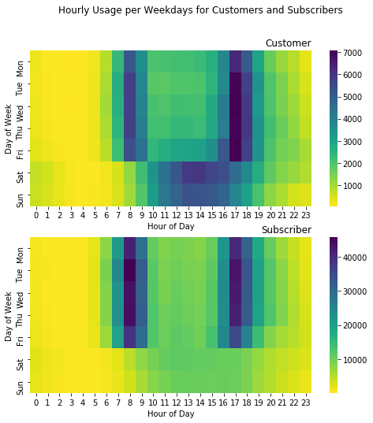

```python
plt.subplots(figsize=(8,8))
plt.suptitle('Hourly Usage per Weekdays for Customers and Subscribers')

plt.subplot(2, 1, 1)
customers = df_cleaned.query('user_type == "Customer"')
cust_counts = customers.groupby(['weekday', 'hour']).size()
cust_counts = cust_counts.reset_index(name = 'count')
cust_counts = cust_counts.pivot(index='weekday', columns='hour', values='count')
sns.heatmap(cust_counts, cmap='viridis_r');
plt.title('Customer', loc='right');
plt.xlabel('Hour of Day');
plt.ylabel('Day of Week');

plt.subplot(2, 1, 2)
subscribers = df_cleaned.query('user_type == "Subscriber"')
sub_counts = subscribers.groupby(['weekday', 'hour']).size()
sub_counts = sub_counts.reset_index(name='count')
sub_counts = sub_counts.pivot(index = 'weekday', columns='hour', values='count')
sns.heatmap(sub_counts, cmap='viridis_r');
plt.title('Subscriber', loc = 'right');
plt.xlabel('Hour of Day');
plt.ylabel('Day of Week');
```

The heatmaps show that subscribers use the system a lot on working days, Monday to Friday whereas customers ride a lot on weekends, especially in the afternoon between 11:00 AM to 16:00 PM. But on the working days they also use it in the morning customoers. Many trips are between 8:00 to 10:00 AM and 16:00 to 18:00 PM on working days. Therefore, we can conlude that custommers prefer weekend afternoons more than subscribers, however, subscribers uses more bikes in the weekdays in the morning and afternnoon, the reason might be for working or school.